# Proyecto INF449 – Single Pixel Camera: cuántas mediciones necesita una escena

INF449 · Fotografía Computacional · Proyecto final

Comprimir la captura:  
cámara de un píxel y reconstrucción 2D

Francisco Alfaro · Ayrton Perez

Universidad Técnica Federico Santa María · Departamentos de Electrónica e Informática

Código: github.com/fralfaro/inf449-proyecto

## Una cámara de un píxel cambia sensor por mediciones

Contexto · Problema y pregunta

Problema

Un sensor matricial es caro en ciertas bandas. La **SPC** usa **un solo detector** y una secuencia de **patrones** de iluminación [1, 2].

Brecha

El precio es el tiempo: **cada vista exige muchas mediciones**, y una escena 3D necesita cientos de vistas.

Pregunta

¿Cuánta calidad se pierde al **reducir las mediciones por vista**, y qué patrón y qué reconstrucción lo soportan mejor?

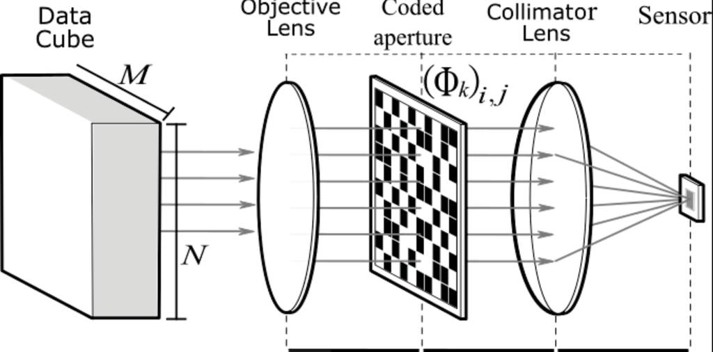

## Estado del arte: de la arquitectura de Rice a la imagen 3D

Contexto · Single Pixel Camera

| Año | Trabajo | Aporte |
| --- | --- | --- |
| 2006 | Donoho [3] | Base teórica: muestreo comprimido y recuperación con ℓ₁ |
| 2008 | Duarte et al. [1] | Cámara de un píxel: un DMD y un fotodiodo con muestreo comprimido |
| 2013 | Sun et al. [4] | Imagen 3D con detectores de un píxel |
| 2017 | Zhang et al. [5] | Hadamard frente a Fourier para imagen de un píxel |
| 2019 | Edgar, Gibson, Padgett [2] · Yu [6] | Revisión del campo; orden *cake-cutting* sub-Nyquist |

## Cada medición es un producto interno con un patrón

Método · Modelo de medición

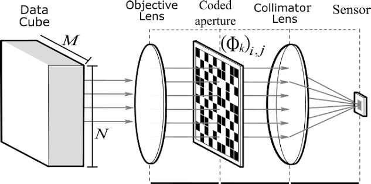

Arquitectura de una SPC. Fuente: material del curso.

Medición con ruido

$$\mathbf{y}=\mathbf{\Phi}\mathbf{x}+\mathbf{n},\qquad r=\frac{M}{N}$$

Un DMD solo tiene máscaras {0,1}

$$\mathbf{P}=\tfrac{1}{2}(\mathbf{1}+\mathbf{H}),\qquad c = 2y-\mathrm{DC}$$

$\mathbf{x}$ es la vista (rejilla **512×1024**, $N=524\,288$); $r$ es la **razón de medición**.

Se mide también el nivel **DC** para recuperar el coeficiente en ±1.

Esa corrección **duplica el ruido**, un efecto que suele omitirse.

## Muestreo comprimido: pocas mediciones si la imagen es escasa

Método · Fundamento teórico [3]

Si $\mathbf{x}$ es $K$-escasa y $\mathbf{\Phi}$ cumple RIP

$$M\ \ge\ C\,K\log\!\frac{N}{K}$$

Recuperación

$$\hat{\mathbf{x}}=\arg\min_{\mathbf{x}}\ \|\mathbf{x}\|_1\ \ \text{s.a.}\ \ \|\mathbf{\Phi}\mathbf{x}-\mathbf{y}\|_2\le\varepsilon$$

Las imágenes naturales son escasas en una base adecuada (wavelet, gradiente).

En la práctica se usa **TV**: la escasez está en el gradiente, no en los píxeles.

Con un patrón ordenado la teoría no aplica tal cual; se evalúa de forma **empírica**.

## La base de Hadamard: ortogonal, binaria y rápida

Método · Patrones

[figure not shown]

Patrones de Hadamard. Fuente: material del curso.

Construcción de Sylvester

$$\mathbf{H}_{2n}=\begin{bmatrix}\mathbf{H}_n&\mathbf{H}_n\\\mathbf{H}_n&-\mathbf{H}_n\end{bmatrix},\quad \mathbf{H}_1=[1]$$

Ortogonalidad

$$\mathbf{H}\mathbf{H}^{\top}=N\,\mathbf{I}\ \Rightarrow\ \mathbf{\Phi}\mathbf{\Phi}^{\top}=\mathbf{I}$$

Exige $N$ potencia de 2 (de ahí la rejilla 512×1024) y permite una transformada rápida.

## Un DMD solo muestra 0 y 1: patrón positivo y negativo

Método · Hadamard en un DMD

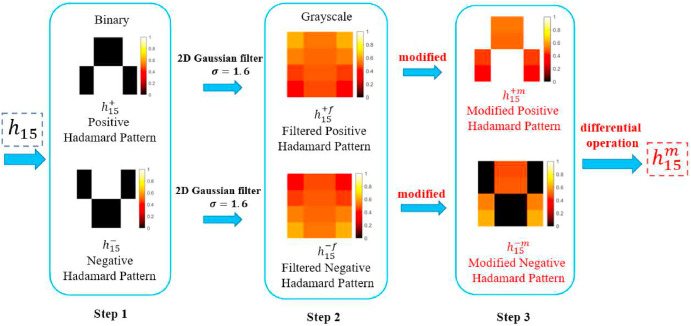

Separación en patrón positivo y negativo, con filtro gaussiano. Fuente: figura del material de ejemplo; verificar.

Patrón ±1 con máscaras {0,1}

$$\mathbf{h}=\mathbf{h}^{+}-\mathbf{h}^{-},\qquad \mathbf{h}^{\pm}\in\{0,1\}^{N}$$

Esquema usado aquí: un patrón + referencia DC

$$c=2y-y_{\mathrm{DC}}$$

La versión **diferencial** mide $\mathbf{h}^{+}$ y $\mathbf{h}^{-}$: el doble de mediciones.

Aquí se mide **un patrón y el nivel DC**: menos mediciones, pero el ruido se duplica.

La óptica **difumina** el patrón; la figura lo modela con un filtro gaussiano ($\sigma=1{,}6$).

## El orden de los patrones decide qué se mide primero

Método · Órdenes de patrones [5, 6]

Cake-cutting

Ordena las filas por el **número de bloques conexos** del patrón: primero las bajas frecuencias. Un patrón separable $w_i(x)\,w_j(y)$ tiene $(s_i+1)(s_j+1)$ bloques.

Russian dolls

Orden por **escala** anidada; buena resolución con pocas mediciones.

Fourier y aleatorio

Fourier necesita **4 pasos** por coeficiente (4N mediciones); el binario aleatorio no prioriza frecuencias y se implementa con permutación + Hadamard + submuestreo.

En este trabajo se comparan **Hadamard ordenado (cake-cutting)** y **binario aleatorio estructurado**.

## Ruido del detector: Poisson, lectura y cuantización

Método · Modelo físico

Medición del fotodiodo

$$y_i=Q_b\!\left(\frac{\mathrm{Pois}\!\big(\gamma\,\langle\mathbf{p}_i,\mathbf{x}\rangle\big)}{\gamma}+\mathcal{N}(0,\sigma^2)\right)$$

Coeficiente en ±1

$$c_i = 2y_i-y_{\mathrm{DC}}\ \Rightarrow\ \sigma_c = 2\sigma_y$$

$\gamma=10^{9}$ fotones por patrón; ruido de lectura $\sigma=10^{-5}$.

$Q_b$: cuantización de **16 bits**; la referencia DC se promedia 16 veces.

Con estos parámetros el ruido no domina: el límite es la **cantidad de mediciones**.

## Directa: mínima norma. Regularizada: variación total

Método · Reconstrucción [7]

Directa

$$\hat{\mathbf{x}}=\mathbf{\Phi}^{\top}\mathbf{y}$$

Equivale a rellenar con ceros los coeficientes no medidos.

Regularizada con TV

$$\hat{\mathbf{x}}=\arg\min_{\mathbf{x}}\ \tfrac12\|\mathbf{\Phi}\mathbf{x}-\mathbf{y}\|_2^2+\lambda\,\mathrm{TV}(\mathbf{x})$$

$$\mathrm{TV}(\mathbf{x})=\sum_{i,j}\sqrt{(\nabla_h x)_{ij}^2+(\nabla_v x)_{ij}^2}$$

$\lambda$ se elige con vistas de **entrenamiento** (rejilla $10^{-3}$ a $3\times10^{-2}$) y se fija antes de evaluar.

## FISTA resuelve el problema con convergencia acelerada

Método · Algoritmo [8]

Paso proximal con el gradiente del ajuste

$$\mathbf{x}_k=\mathrm{prox}_{\frac{\lambda}{L}\mathrm{TV}}\!\Big(\mathbf{z}_k-\tfrac1L\mathbf{\Phi}^{\top}(\mathbf{\Phi}\mathbf{z}_k-\mathbf{y})\Big)$$

Aceleración

$$t_{k+1}=\frac{1+\sqrt{1+4t_k^2}}{2}$$

$$\mathbf{z}_{k+1}=\mathbf{x}_k+\frac{t_k-1}{t_{k+1}}(\mathbf{x}_k-\mathbf{x}_{k-1})$$

Convergencia $O(1/k^2)$ frente a $O(1/k)$ del gradiente proximal simple.

El proximal de TV se resuelve con **FGP** (gradiente rápido proyectado), en lotes en GPU.

Con $\mathbf{\Phi}\mathbf{\Phi}^{\top}=\mathbf{I}$ el paso es $L=1$. Tope de **100 iteraciones**.

## Diseño experimental: escenas, condiciones y recursos

Experimentos · Diseño

| Elemento | Valor |
| --- | --- |
| Escenas | Truck, Train (Tanks and Temples); DrJohnson, Playroom (Deep Blending) [10] |
| Vistas | 24 por escena, equiespaciadas |
| Razones de medición | 5 %, 10 %, 25 %, 50 % |
| Patrones × métodos | Hadamard ordenado, aleatorio × directa, TV |
| Control | Solo remuestreo a 512×1024 (sin SPC) |
| Hardware | RTX 4060 Laptop 8 GB · PyTorch 2.11 + CUDA 12.8 |
| Tiempo | 12–15 min por escena (24 vistas, todas las condiciones); 53 min las cuatro |

## Métricas: error de señal, estructura y percepción

Experimentos · Métricas

PSNR

$$\mathrm{PSNR}=10\log_{10}\frac{1}{\mathrm{MSE}(\hat{\mathbf{x}},\mathbf{x})}\ \text{dB}$$

SSIM

$$\mathrm{SSIM}=\frac{(2\mu_a\mu_b+c_1)(2\sigma_{ab}+c_2)}{(\mu_a^2+\mu_b^2+c_1)(\sigma_a^2+\sigma_b^2+c_2)}$$

**PSNR**: error de píxel; sensible a ruido de baja amplitud.

**SSIM**: estructura local (luminancia, contraste, correlación).

**LPIPS-VGG**: distancia entre características de una red; mide **percepción**.

Siempre contra la imagen **original**, a la resolución final.

## Con 25 % de las mediciones la escena sigue reconocible

Resultados · Truck, Hadamard + TV

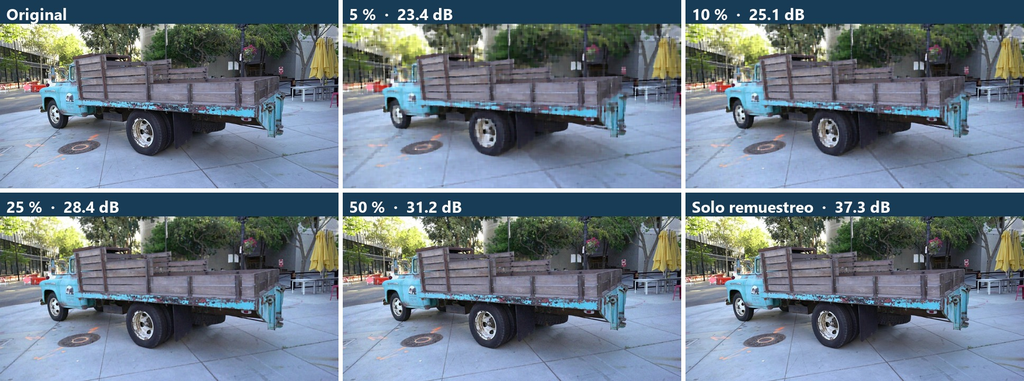

Al **5 %** aparecen bloques en zonas de textura (follaje).

Desde el **25 %** los bordes del camión se conservan.

Vista 000001; el PSNR es el de esa vista.

## Calidad frente a razón de medición

Resultados · Truck, 24 vistas

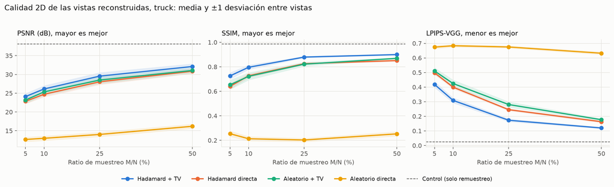

Media y ±1 desviación entre vistas. Línea punteada: control.

## La regularización importa más con patrones aleatorios

Resultados · Truck, PSNR medio (dB) en 24 vistas

| Patrón · método | 5 % | 10 % | 25 % | 50 % |
| --- | --- | --- | --- | --- |
| Hadamard · directa | 22,84 | 24,72 | 28,04 | 30,85 |
| Hadamard · TV | 24,11 | 26,13 | 29,55 | 32,10 |
| Aleatorio · directa | 12,68 | 12,99 | 14,02 | 16,19 |
| Aleatorio · TV | 23,18 | 25,35 | 28,49 | 31,05 |
| Control (solo remuestreo) | 38,07 |  |  |  |

≈ +1,3 dB

TV frente a directa, con Hadamard

Con patrones aleatorios, la directa no sirve (**13–16 dB**); la TV la lleva a **23–31 dB**.

## Con cuatro escenas la tendencia se mantiene

Resultados · Media de 4 escenas × 24 vistas

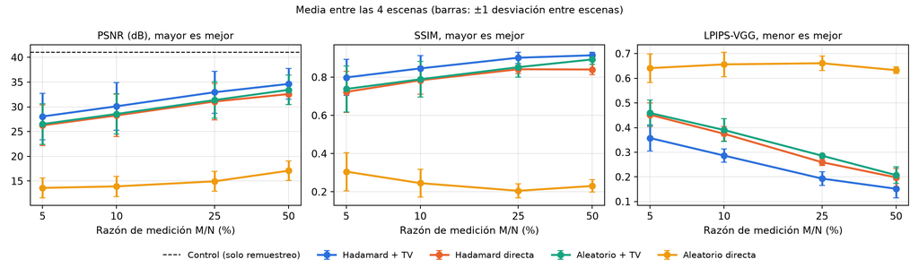

28,1 → 34,6 dB

Hadamard + TV, del 5 % al 50 %

La TV aporta **1,8 a 2,1 dB** sobre la directa; el aleatorio + TV llega a **33,4 dB** al 50 %.

## La escena influye más que el método

Resultados · Hadamard + TV por escena

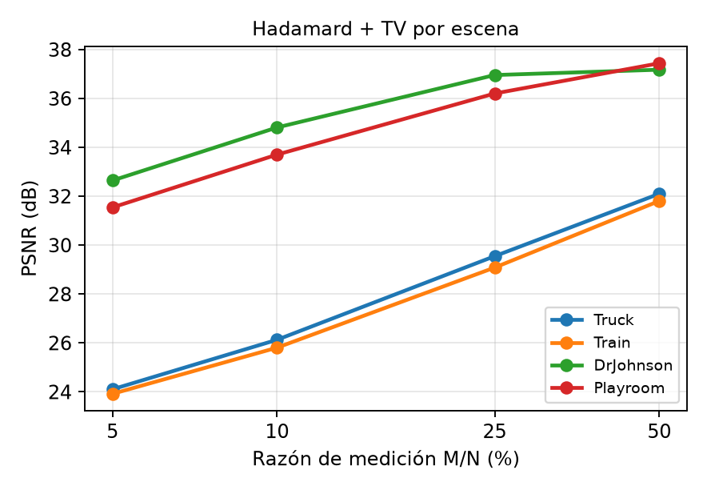

Al 5 %: **23,9 dB** (Train) frente a **32,6 dB** (DrJohnson).

El **control de remuestreo** muestra la misma separación: 37,7 y 38,1 dB frente a 44,9 y 43,5 dB.

Hipótesis (sin verificar): Deep Blending tiene mayor resolución nativa y se suaviza al llevarla a la rejilla.

## Qué hace cada reconstrucción con la misma medición

Resultados · Truck al 10 %

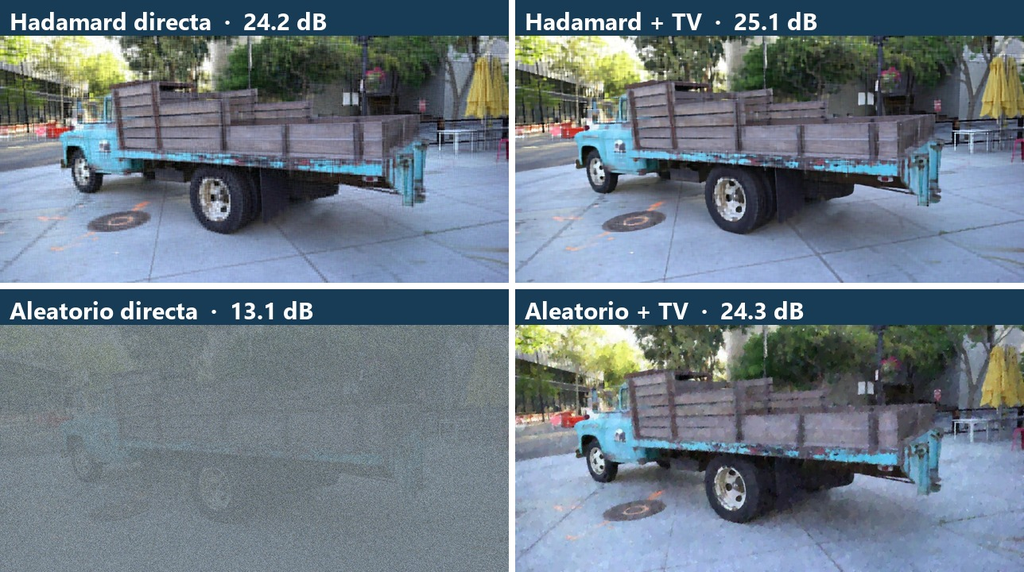

Aleatorio + directa: **ruido** sin estructura.

Hadamard + directa: imagen con **artefactos de bloque**.

Con TV los bordes se limpian en ambos patrones.

## 3DGS parte de una nube de puntos y la convierte en gaussianas

Motivación · De puntos a gaussianas [9]

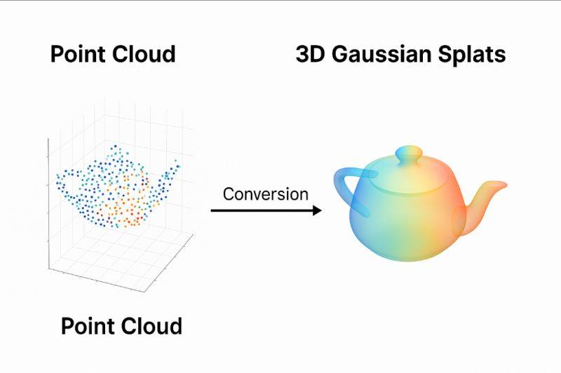

Ilustración conceptual; sin fuente identificada.

**COLMAP** entrega las poses y una nube de puntos dispersa (**136 029** puntos en Truck).

Cada punto se inicializa como una **gaussiana 3D** con color y opacidad.

La optimización las **mueve, estira, divide y poda** hasta reproducir las vistas.

## El destino de las vistas: 3D Gaussian Splatting

Motivación · Del 2D al 3D [9]

[figure not shown]

Pipeline de 3D-GS. Figura tomada del material de ejemplo de la presentación; verificar su fuente antes de exponer.

## De gaussianas 3D a una imagen: proyectar y mezclar

Motivación · Renderizado de 3DGS [9]

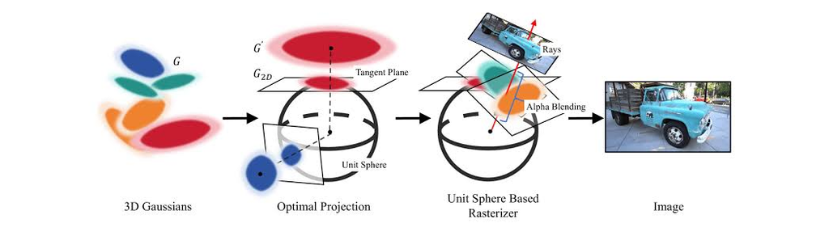

Variante con proyección sobre la esfera unitaria. Fuente: material de ejemplo; verificar antes de exponer.

La escena es un conjunto de **gaussianas 3D** con color y opacidad.

Cada una se **proyecta** al plano de la imagen como una elipse 2D.

Se **mezclan con alfa**, de adelante hacia atrás, para formar cada píxel.

## Cada gaussiana es un elipsoide con color y opacidad

Motivación · Representación de 3DGS [9]

Gaussiana 3D y covarianza

$$G(\mathbf{x})=\exp\!\Big(-\tfrac12(\mathbf{x}-\boldsymbol{\mu})^{\top}\mathbf{\Sigma}^{-1}(\mathbf{x}-\boldsymbol{\mu})\Big),\quad \mathbf{\Sigma}=\mathbf{R}\mathbf{S}\mathbf{S}^{\top}\mathbf{R}^{\top}$$

Proyección a la imagen

$$\mathbf{\Sigma}'=\mathbf{J}\mathbf{W}\mathbf{\Sigma}\mathbf{W}^{\top}\mathbf{J}^{\top}$$

Composición $\alpha$ de $i$ gaussianas ordenadas

$$C=\sum_{i}c_i\,\alpha_i\prod_{j<i}(1-\alpha_j)$$

Pérdida de entrenamiento

$$\mathcal{L}=(1-\lambda)\,\mathcal{L}_1+\lambda\,\mathcal{L}_{\text{D-SSIM}},\quad \lambda=0{,}2$$

**59 parámetros** por gaussiana: posición (3), rotación (4), escala (3), opacidad (1) y armónicos esféricos (48).

## Cómo se conectan la SPC y 3DGS en este proyecto

Motivación · Flujo completo

1 · Medir

Simular la SPC en cada vista con razón $r$ y reconstruirla (directa o TV).

2 · Preparar

Conservar los **nombres y poses COLMAP** del dataset y filtrar `images.bin` al usar un subconjunto.

3 · Entrenar y comparar

Entrenar 3DGS con las vistas degradadas y evaluar contra el **original**: ¿cómo se propaga el error a 3D?

Referencia del artículo de 3DGS en Truck: **25,19 dB** / SSIM 0,879 / LPIPS 0,148 a 30 000 iteraciones, en una GPU A6000.

## Alcance, limitaciones y conclusiones

Análisis crítico y conclusiones

Aporta

Simulación SPC cercana a la resolución nativa, con ruido de DMD, y comparación de **patrones y reconstrucción**.

Limitaciones

Vistas ya capturadas (JPEG), medición en **sRGB**, escena estática, **pocas vistas**; en 3D, **poses y nube del GT** (cota optimista).

Siguiente paso

Ejecutar 3DGS con las corridas SPC y medir la propagación 2D → 3D; re-estimar poses sin el GT.

Hadamard ordenado + TV es la mejor combinación en las tres métricas (34,6 dB al 50 %); la TV es **imprescindible** con patrones aleatorios (13,6 → 26,5 dB al 5 %).

## Referencias

Respaldo · Numeración de esta presentación

**[1]** Duarte et al., «Single-pixel imaging via compressive sampling», *IEEE SPM*, 2008.

**[2]** Edgar, Gibson y Padgett, «Principles and prospects for single-pixel imaging», *Nat. Photonics*, 2019.

**[3]** Donoho, «Compressed sensing», *IEEE Trans. Inf. Theory*, 2006.

**[4]** Sun et al., «3D computational imaging with single-pixel detectors», *Science*, 2013.

**[5]** Zhang et al., «Hadamard single-pixel imaging versus Fourier single-pixel imaging», *Opt. Express*, 2017.

**[6]** Yu, «Super sub-Nyquist single-pixel imaging by means of cake-cutting Hadamard basis sort», *Sensors*, 2019.

**[7]** Rudin, Osher y Fatemi, «Nonlinear total variation based noise removal algorithms», *Physica D*, 1992.

**[8]** Beck y Teboulle, «A fast iterative shrinkage-thresholding algorithm», *SIAM J. Imaging Sci.*, 2009.

**[9]** Kerbl et al., «3D Gaussian Splatting for Real-Time Radiance Field Rendering», *ACM TOG*, 2023.

**[10]** Knapitsch et al., «Tanks and Temples», *ACM TOG*, 2017; Hedman et al., «Deep Blending», *ACM TOG*, 2018.

INF449 · Fotografía Computacional · Proyecto final

Comprimir la captura:  
cámara de un píxel y reconstrucción 2D

Francisco Alfaro · Ayrton Perez

Universidad Técnica Federico Santa María · Departamentos de Electrónica e Informática

Código: github.com/fralfaro/inf449-proyecto